# STAT 540 Seminar 04: Two group comparisons and data aggregation

## STAT 540 Seminar 04: Two group comparisons and data aggregation

### Hao Chen

**2014-02-10**

- Load the photoRec dataset and required packages
- The “you try” question
- Take-home problem

> The R markdown file can be found on my [Github](https://github.com/nelsonch/stat540-2014-chen-hao/blob/master/seminar%2004/seminar04.Rmd).

### Load the photoRec dataset and required packages

The following datasets will be covered in this seminar:

- GSE4051_data.tsv: full data matrix
- GSE4051_design.rds: experimental design

Load required datasets:

```r
> prDat <- read.table("GSE4051_data.tsv")
> str(prDat, max.level = 0)
```

```
'data.frame':   29949 obs. of  39 variables:
```

```r
> prDes <- readRDS("GSE4051_design.rds")
> str(prDes)
```

```
'data.frame':   39 obs. of  4 variables:
 $ sidChar : chr  "Sample_20" "Sample_21" "Sample_22" "Sample_23" ...
 $ sidNum  : num  20 21 22 23 16 17 6 24 25 26 ...
 $ devStage: Factor w/ 5 levels "E16","P2","P6",..: 1 1 1 1 1 1 1 2 2 2 ...
 $ gType   : Factor w/ 2 levels "wt","NrlKO": 1 1 1 1 2 2 2 1 1 1 ...
```

Load required R packages:

```r
> library(lattice)   # for plotting
> library(plyr)  # for data aggregation
> library(xtable) # for table display
> library(limma)  # for venn diagram
```

### The “you try” question

[You try](http://ugrad.stat.ubc.ca/%7Estat540/seminars/seminar04_compileNotebook-dataAggregation-twoGroupComparison.html#two-sample-tests----one-gene): Draw a different gene at random. Use the t test, with and without the common variance assumption, the Wilcoxon, and/or the Kolmogorov-Smirnov test to assess differential expression. Pull test statistics and/or p-values from the different approaches into an common object, like a readable table. Hint: wilcox.test(), ks.test().

```r
> set.seed(540)
> (theGene <- sample(1:nrow(prDat), 1))
```

```
[1] 1594
```

```r
> pDat <- data.frame(prDes, gExp = unlist(prDat[theGene, ]))
```

Make a stripplot to sanity test the t test result.

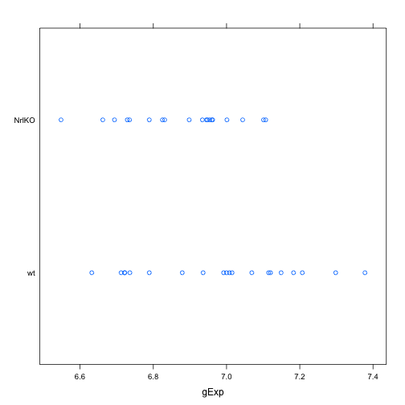

```r
> stripplot(gType ~ gExp, pDat)
```

```r
> ttRes <- t.test(gExp ~ gType, pDat)
> wtRes <- wilcox.test(gExp ~ gType, pDat)
> ksRes <- with(pDat, ks.test(gExp[gType == "NrlKO"], gExp[gType == "wt"]))
> Res <- data.frame(method = c("t.test", "wilcox.test", "ks.test"),
+                   test.stat = c(ttRes$stat, wtRes$stat, ksRes$stat),
+                   p.value = c(ttRes$p.val, wtRes$p.val, ksRes$p.val))
> htmlPrint(Res, digits = 3)
```

| method | test.stat | p.value |
| --- | --- | --- |
| t.test | 1.788 | 0.083 |
| wilcox.test | 250.500 | 0.092 |
| ks.test | 0.389 | 0.104 |

### Take-home problem ([link here](http://ugrad.stat.ubc.ca/%7Estat540/seminars/seminar04_compileNotebook-dataAggregation-twoGroupComparison.html#ideas-for-take-home-work))

#### Step 1: Make a numeric matrix with p-values for 100 randomly picked genes for various two-group tests (t.test, wilcox.test and ks.test).

Randomly draw 100 genes and aggregate the data.

```r
> set.seed(540)
> theGenes <- sample(1:nrow(prDat), 100)
> keepGenes <- rownames(prDat)[theGenes]
> miniDat <- subset(prDat, rownames(prDat) %in% keepGenes)
> miniDat <- data.frame(gExp = as.vector(t(as.matrix(miniDat))),
+                       gene = factor(rep(rownames(miniDat), each = ncol(miniDat)),
+                                     levels = keepGenes))
> miniDat <- suppressWarnings(data.frame(prDes, miniDat))
> str(miniDat)
```

```
'data.frame':   3900 obs. of  6 variables:
 $ sidChar : chr  "Sample_20" "Sample_21" "Sample_22" "Sample_23" ...
 $ sidNum  : num  20 21 22 23 16 17 6 24 25 26 ...
 $ devStage: Factor w/ 5 levels "E16","P2","P6",..: 1 1 1 1 1 1 1 2 2 2 ...
 $ gType   : Factor w/ 2 levels "wt","NrlKO": 1 1 1 1 2 2 2 1 1 1 ...
 $ gExp    : num  6.84 6.33 6.52 6.56 6.81 ...
 $ gene    : Factor w/ 100 levels "1417558_at","1453147_at",..: 11 11 11 11 11 11 11 11 11 11 ...
```

The p-values for various two-group tests. The results are sorted by *t* test.

```r
> Res <- ddply(miniDat, ~ gene, function(x){
+   ttRes <- t.test(gExp ~ gType, x)
+   wtRes <- wilcox.test(gExp ~ gType, x)
+   ksRes <- with(x, ks.test(gExp[gType == "NrlKO"], gExp[gType == "wt"]))
+   round(c(t.test = ttRes$p.val, wilcox.test = wtRes$p.val, ks.test = ksRes$p.val), 3)
+ })
> Res <- arrange(Res, t.test)
> htmlPrint(Res, digits = 3)
```

| gene | t.test | wilcox.test | ks.test |
| --- | --- | --- | --- |
| 1457524_at | 0.000 | 0.000 | 0.000 |
| 1444617_at | 0.001 | 0.001 | 0.001 |
| 1435030_at | 0.004 | 0.008 | 0.051 |
| 1417923_at | 0.005 | 0.004 | 0.011 |
| 1438107_x_at | 0.017 | 0.025 | 0.113 |
| 1448090_at | 0.025 | 0.061 | 0.132 |
| 1458637_x_at | 0.026 | 0.041 | 0.123 |
| 1440749_at | 0.028 | 0.060 | 0.122 |
| 1453147_at | 0.030 | 0.053 | 0.197 |
| 1459539_at | 0.041 | 0.041 | 0.034 |
| 1456736_x_at | 0.046 | 0.074 | 0.377 |
| 1419588_at | 0.049 | 0.044 | 0.008 |
| 1417183_at | 0.065 | 0.074 | 0.282 |
| 1421541_a_at | 0.067 | 0.100 | 0.055 |
| 1449127_at | 0.081 | 0.046 | 0.023 |
| 1417558_at | 0.083 | 0.092 | 0.104 |
| 1423132_a_at | 0.091 | 0.267 | 0.190 |
| 1451363_a_at | 0.096 | 0.084 | 0.049 |
| 1446571_at | 0.101 | 0.032 | 0.046 |
| 1447521_x_at | 0.103 | 0.034 | 0.042 |
| 1432182_at | 0.104 | 0.043 | 0.053 |
| 1419159_at | 0.132 | 0.296 | 0.104 |
| 1446961_at | 0.148 | 0.235 | 0.571 |
| 1447640_s_at | 0.151 | 0.040 | 0.023 |
| 1430577_at | 0.161 | 0.187 | 0.227 |
| 1449162_at | 0.174 | 0.211 | 0.388 |
| 1453720_at | 0.187 | 0.184 | 0.427 |
| 1418200_at | 0.194 | 0.296 | 0.417 |
| 1436746_at | 0.205 | 0.160 | 0.355 |
| 1448647_at | 0.213 | 0.279 | 0.422 |

[output cut: 70 more lines]

The following figures show the first 3 clear 'hits' and last 3 clear boring genes from the randomly sampled 100 genes, according to the p-value from *t* test.

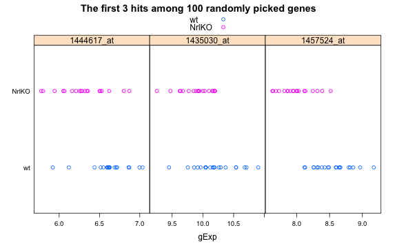

```r
> hitGene <- Res$gene[1:3]
> hitDat <- subset(miniDat, gene %in% hitGene)
> borGene <- Res$gene[98:100]
> borDat <- subset(miniDat, gene %in% borGene)
> stripplot(gType ~ gExp | gene, hitDat, group = gType, auto.key = TRUE,
+           scales = list(x = list(relation = "free")), layout = c(3, 1),
+           main = "The first 3 hits among 100 randomly picked genes")
```

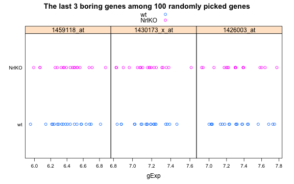

```r
> stripplot(gType ~ gExp | gene, borDat, group = gType, auto.key = TRUE,
+           scales = list(x = list(relation = "free")), layout = c(3, 1),
+           main = "The last 3 boring genes among 100 randomly picked genes")
```

#### Step 2: Scatterplot different kinds of p-values against each other.

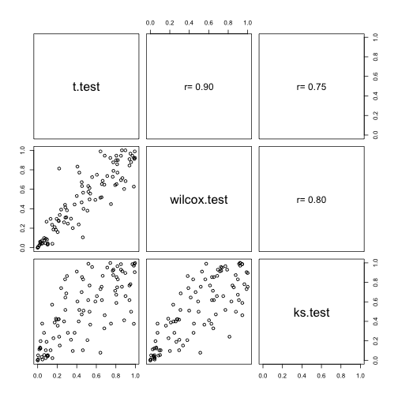

```r
> pairDat <- Res[, c("t.test", "wilcox.test", "ks.test")]
> panel.cor <- function(x, y, digits=2, cex.cor)
+ {
+   usr <- par("usr"); on.exit(par(usr))
+   par(usr = c(0, 1, 0, 1))
+   r <- abs(cor(x, y))
+   txt <- format(c(r, 0.123456789), digits=digits)[1]
+   text(0.5, 0.5, paste("r=",txt), cex=1.5)
+ }
> pairs(pairDat, upper.panel=panel.cor)
```

#### Step 3: Convert your numeric matrix of p-values into a matrix of TRUE/FALSE or zeros and ones by hard-threshholding, e.g. conventional 0.05 level, and make some interesting row or column summaries.

Convert the above matrix of p-values into a matrix of 1/0 (1 stands for significance), the cut-off p-value is 0.05. The following table shows the first 10 rows of such a table.

```r
> cutoff <- 0.05
> sumRes <- Res[, c("t.test", "wilcox.test", "ks.test")]
> sumRes <- matrix(as.numeric(sumRes < cutoff), nrow = nrow(sumRes))
> colnames(sumRes) <- c("t.test", "wilcox.test", "ks.test")
> tfRes <- data.frame(gene = Res$gene, as.data.frame(sumRes))
> htmlPrint(tfRes[1:10, ])
```

| gene | t.test | wilcox.test | ks.test |
| --- | --- | --- | --- |
| 1457524_at | 1 | 1 | 1 |
| 1444617_at | 1 | 1 | 1 |
| 1435030_at | 1 | 1 | 0 |
| 1417923_at | 1 | 1 | 1 |
| 1438107_x_at | 1 | 1 | 0 |
| 1448090_at | 1 | 0 | 0 |
| 1458637_x_at | 1 | 1 | 0 |
| 1440749_at | 1 | 0 | 0 |
| 1453147_at | 1 | 0 | 0 |
| 1459539_at | 1 | 1 | 1 |

How many genes are significant according to the different tests?

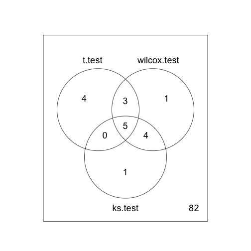

```r
> vennDiagram(vennCounts(sumRes[, c("t.test", "wilcox.test", "ks.test")]))
```

Show the 18 genes which are significant from at least one of the tests.

```r
> testsum <- rowSums(sumRes)
> sumRes <- as.data.frame(sumRes)
> sumRes <- cbind(gene = Res$gene, sumRes, sum.test = testsum)
> hitRes <- arrange(subset(sumRes, sum.test > 0), desc(sum.test))
> htmlPrint(hitRes)
```

| gene | t.test | wilcox.test | ks.test | sum.test |
| --- | --- | --- | --- | --- |
| 1457524_at | 1 | 1 | 1 | 3 |
| 1444617_at | 1 | 1 | 1 | 3 |
| 1417923_at | 1 | 1 | 1 | 3 |
| 1459539_at | 1 | 1 | 1 | 3 |
| 1419588_at | 1 | 1 | 1 | 3 |
| 1435030_at | 1 | 1 | 0 | 2 |
| 1438107_x_at | 1 | 1 | 0 | 2 |
| 1458637_x_at | 1 | 1 | 0 | 2 |
| 1449127_at | 0 | 1 | 1 | 2 |
| 1446571_at | 0 | 1 | 1 | 2 |
| 1447521_x_at | 0 | 1 | 1 | 2 |
| 1447640_s_at | 0 | 1 | 1 | 2 |
| 1448090_at | 1 | 0 | 0 | 1 |
| 1440749_at | 1 | 0 | 0 | 1 |
| 1453147_at | 1 | 0 | 0 | 1 |
| 1456736_x_at | 1 | 0 | 0 | 1 |
| 1451363_a_at | 0 | 0 | 1 | 1 |
| 1432182_at | 0 | 1 | 0 | 1 |

The following figure shows the stripplot of the 18 'hits' among 100 randomly picekd genes.

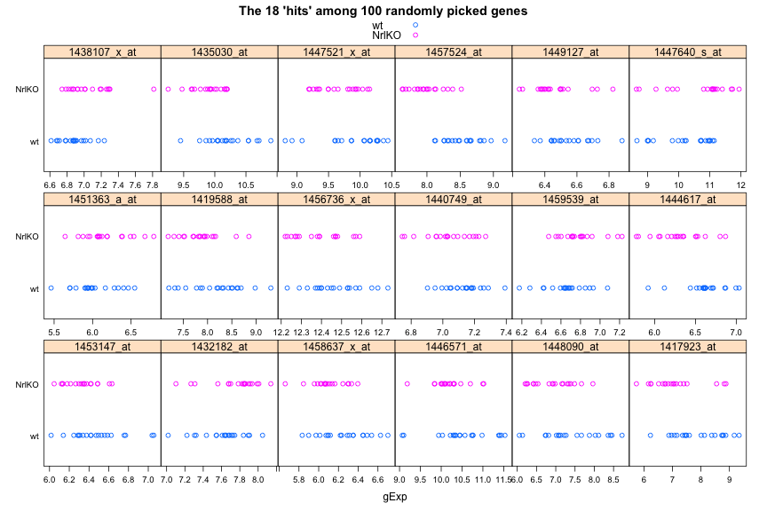

```r
> hitGene <- hitRes$gene
> hitDat <- subset(miniDat, gene %in% hitGene)
> stripplot(gType ~ gExp | gene, hitDat, group = gType, auto.key = TRUE,
+           scales = list(x = list(relation = "free")), layout = c(6, 3),
+           main = "The 18 'hits' among 100 randomly picked genes")
```